# Assignment 3 - Task 3

Erin de Leon Sanchez

10/26/2021

# Overview

In this task, I use version control, project management, and data wrangling, analysis & visualization skills to explore red and purple urchins recorded by Santa Barbara Coastal Long Term Ecological Research program divers, while practicing version control and project management.

Data citation: Reed, D. 2020. SBC LTER: Reef: Long-term experiment: Kelp removal: Urchin size frequency distribution ver 20. Environmental Data Initiative. https://doi.org/10.6073/pasta/5a1e9ef03aa47bd2225c0bb98a02a63b.

# Set up

```r
knitr::opts_chunk$set(echo = TRUE, message = FALSE, warning = FALSE)

library(tidyverse)
library(here)
library(kableExtra)
library(lubridate)
library(janitor)
```

# Read in data

```r
urchins <- read_csv(here("data", "urchins.csv"))
```

# Section 1:

Size comparisons, purple and red urchins (includes data from all sites, and for both treatments - i.e. ignore those variables here)

## i. Data visualization:

Here I compare the distribution of sizes between purple and red urchins with a finalized, faceted histogram.

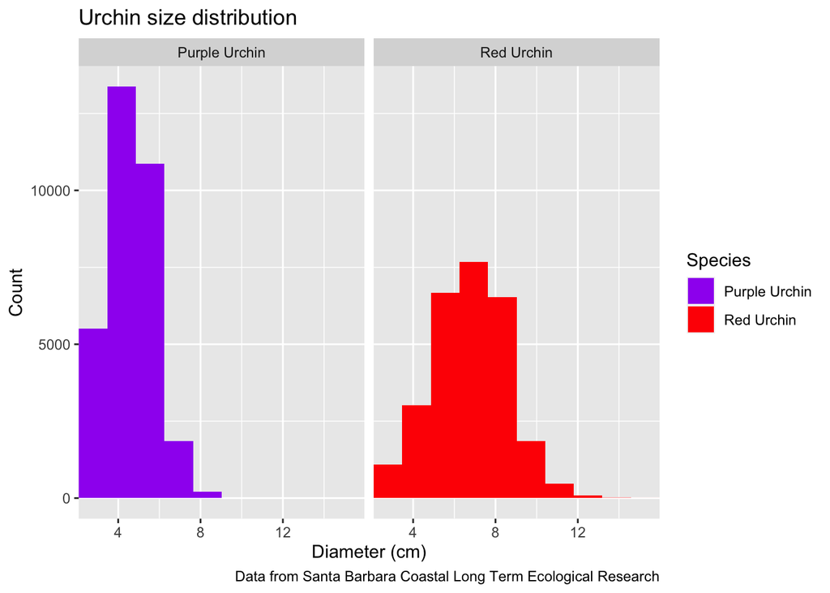

```r
ggplot(data = urchins, aes(x = SIZE, fill = COMMON_NAME)) +
  scale_fill_manual(values = c("purple", "red"), name = "Species") +
  scale_x_continuous(expand = c(0, 0)) +
  geom_histogram(bins = 10) +
  facet_wrap(~ COMMON_NAME) +
  labs(x = "Diameter (cm)", y = "Count", title = "Urchin size distribution", caption = "Data from Santa Barbara Coastal Long Term Ecological Research")
```

## ii. Descriptive statistics table:

Here, I create a descriptive statistics table for purple and red urchins (still ignoring site and treatments as variables, but including species as a grouping variable).

```r
size_summary <- urchins %>%
  group_by(COMMON_NAME) %>%
  summarize(mean_size = mean(SIZE, na.rm = TRUE),
            median_size = median(SIZE, na.rm = TRUE),
            sd_size = sd(SIZE, na.rm = TRUE),
            sample_size = n()
            )

kable(size_summary, col.names = c("Common name", "Mean size (cm)", "Median size (cm)", "Standard deviation (cm)", "Sample size (n)"), digits = 1, caption = "Summary statistics for Santa Barbara Coastal Long-Term Ecological Research data for purple and red urchins") %>%
  kable_classic()
```

Summary statistics for Santa Barbara Coastal Long-Term Ecological Research data for purple and red urchins

| Common name | Mean size (cm) | Median size (cm) | Standard deviation (cm) | Sample size (n) |
| --- | --- | --- | --- | --- |
| Purple Urchin | 4.5 | 4.5 | 1.2 | 31805 |
| Red Urchin | 6.8 | 7.0 | 1.9 | 27408 |

# Section 2:

Exploration of purple urchin counts by site and year.

## Data wrangling

Here, I first filter to only include observations for purple urchins. Then I convert the date to class “Date” so that I can create a new column that only contains the year. Finally, I create a new column called site_full that contains the full site names.

```r
purple_urchins <- urchins %>%
  filter(COMMON_NAME %in% "Purple Urchin") %>%
  mutate(DATE_NEW = as_date(DATE, format="%m/%d/%y")) %>%
  mutate(YEAR = year(DATE_NEW)) %>%
  mutate(site_full = case_when(
    SITE == "NAPL"  ~ "Naples",
    SITE == "AQUE" ~ "Arroyo Quemado",
    SITE == "CARP" ~ "Carpinteria Reef",
    SITE == "MOHK" ~ "Mohawk Reef",
    SITE == "IVEE" ~ "Isla Vista Reef")
  )
```

## Data visualization

Here, I write code to store a table containing the total number of purple urchins observed by site and year.

```r
purple_total <- purple_urchins %>%
  select(site_full, COMMON_NAME, YEAR) %>%
  group_by(site_full, YEAR) %>%
  summarize(COUNT = n())
```

Here, I make a finalized graph of counts of purple urchins recorded at each site over time for the years included in the study.

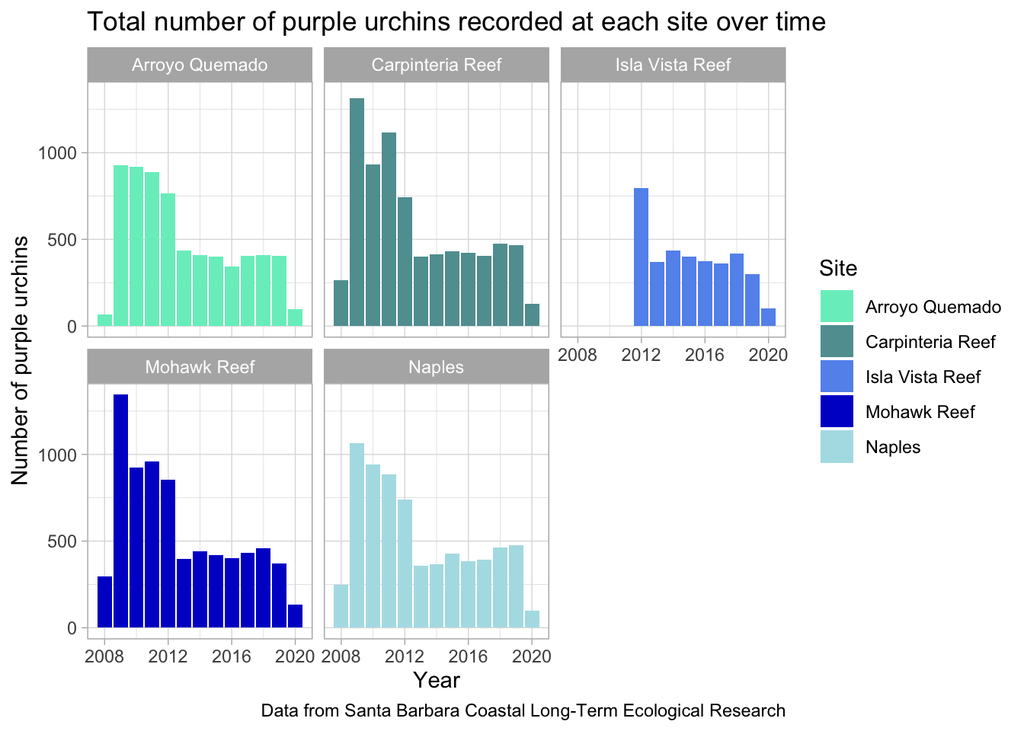

```r
ggplot(data = purple_total, aes(x = YEAR, y = COUNT)) +
  geom_col(position = "dodge2", aes(fill = site_full), legend = "Site") +
  scale_fill_manual(name = "Site", values = c("aquamarine2", "cadetblue", "cornflowerblue", "blue3", "powderblue")) +
  facet_wrap(~ site_full) +
  theme_light() +
  labs(x = "Year", y = "Number of purple urchins" , title = "Total number of purple urchins recorded at each site over time", caption = "Data from Santa Barbara Coastal Long-Term Ecological Research")
```

I think that this graph generally reflects changes in the purple urchin population. However, we have to take into account the treatments (control vs. annual) as variables to determine whether the changes in counts by year are reflective of actual changes in urchin population. Anomalous extreme events, such as marine heatwaves, could explain the changes in number of purple urchins observed over time. Differential urchin recruitment per year could also explain the changes in number of purple urchins over time.